# Projeto 2 - Prevendo a Demanda de Estoque com Base em Vendas

#### autor: Rosane Moreira Barbosa

### Objetivo:

Em resumo, neste projeto em linguagem R, o objetivo é desenvolver um modelo de aprendizado de máquina para prever a demanda de estoque com base nos dados históricos de vendas de produtos de panificação.

*** Descrição das Variáveis ***

Semana —> Week number (From Thursday to Wednesday);

Agencia_ID —> Sales Depot ID;

Canal_ID —> Sales Channel ID;

Ruta_SAK —> Route ID (Several routes = Sales Depot);

Cliente_ID —> Client ID;

NombreCliente —> Client name;

Producto_ID —> Product ID;

NombreProducto —> Product Name;

Venta_uni_hoy —> Sales unit this week (integer);

Venta_hoy —> Sales this week (unit: pesos);

Dev_uni_proxima —> Returns unit next week (integer);

Dev_proxima —> Returns next week (unit: pesos);

Demanda_uni_equil —> Adjusted Demand (integer) (This is the target you will predict)

## Carregando Dados de Treino

Como o tamanho do arquivo de treino é grande (3.6 GB) usaremos uma amostra aleatória dos dados.

A coluna “Demanda_uni_equil” é a nossa variável target.

Verificando se existem valores ausentes (missing) em cada coluna.

```
##            Semana        Agencia_ID          Canal_ID          Ruta_SAK
##                 0                 0                 0                 0
##        Cliente_ID       Producto_ID     Venta_uni_hoy         Venta_hoy
##                 0                 0                 0                 0
##   Dev_uni_proxima       Dev_proxima Demanda_uni_equil
##                 0                 0                 0
```

Verificando os tipos das variáveis

```
## Classes 'data.table' and 'data.frame':   500000 obs. of  11 variables:
##  $ Semana           : int  5 8 4 8 9 7 8 9 6 7 ...
##  $ Agencia_ID       : int  4040 2055 2013 1552 1954 1123 2216 3213 1956 1311 ...
##  $ Canal_ID         : int  1 1 1 1 1 1 1 1 1 1 ...
##  $ Ruta_SAK         : int  2865 1158 2812 1231 1118 1428 1214 1426 1201 1068 ...
##  $ Cliente_ID       : int  1722650 2111926 4712237 162096 558122 405648 601036 4423110 1235904 4255230 ...
##  $ Producto_ID      : int  43307 34050 30572 43202 33370 1212 1242 1278 33370 1160 ...
##  $ Venta_uni_hoy    : int  9 3 2 3 18 1 2 4 3 7 ...
##  $ Venta_hoy        : num  47.5 24 12.5 27.2 86.4 ...
##  $ Dev_uni_proxima  : int  0 0 0 0 0 0 0 0 0 0 ...
##  $ Dev_proxima      : num  0 0 0 0 0 0 0 0 0 0 ...
##  $ Demanda_uni_equil: int  9 3 2 3 18 1 2 4 3 7 ...
##  - attr(*, ".internal.selfref")=<externalptr>
```

## Análise exploratória de dados

Medidas de tendência central das variáveis

```
##      Semana        Agencia_ID       Canal_ID         Ruta_SAK
##  Min.   :3.000   Min.   : 1110   Min.   : 1.000   Min.   :   1
##  1st Qu.:4.000   1st Qu.: 1311   1st Qu.: 1.000   1st Qu.:1161
##  Median :6.000   Median : 1613   Median : 1.000   Median :1287
##  Mean   :5.953   Mean   : 2526   Mean   : 1.387   Mean   :2119
##  3rd Qu.:8.000   3rd Qu.: 2034   3rd Qu.: 1.000   3rd Qu.:2803
##  Max.   :9.000   Max.   :25759   Max.   :11.000   Max.   :9945
##    Cliente_ID        Producto_ID    Venta_uni_hoy        Venta_hoy
##  Min.   :      26   Min.   :   53   Min.   :   0.000   Min.   :    0.00
##  1st Qu.:  357118   1st Qu.: 1242   1st Qu.:   2.000   1st Qu.:   16.76
##  Median : 1190626   Median :30549   Median :   3.000   Median :   30.00
##  Mean   : 1801713   Mean   :20856   Mean   :   7.302   Mean   :   68.30
##  3rd Qu.: 2371382   3rd Qu.:37516   3rd Qu.:   7.000   3rd Qu.:   56.25
##  Max.   :99999999   Max.   :49994   Max.   :4044.000   Max.   :28224.00
##  Dev_uni_proxima      Dev_proxima       Demanda_uni_equil
##  Min.   :   0.0000   Min.   :   0.000   Min.   :   0.000
##  1st Qu.:   0.0000   1st Qu.:   0.000   1st Qu.:   2.000
##  Median :   0.0000   Median :   0.000   Median :   3.000
##  Mean   :   0.1305   Mean   :   1.263   Mean   :   7.215
##  3rd Qu.:   0.0000   3rd Qu.:   0.000   3rd Qu.:   6.000
##  Max.   :1100.0000   Max.   :7546.000   Max.   :4044.000
```

Verifica-se que existem alguns outliers nos boxplots das variáveis Agencia_ID e Ruta_SAK.

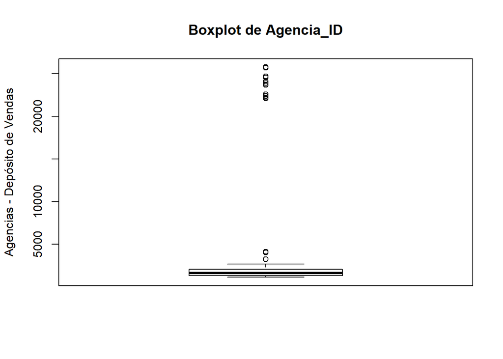

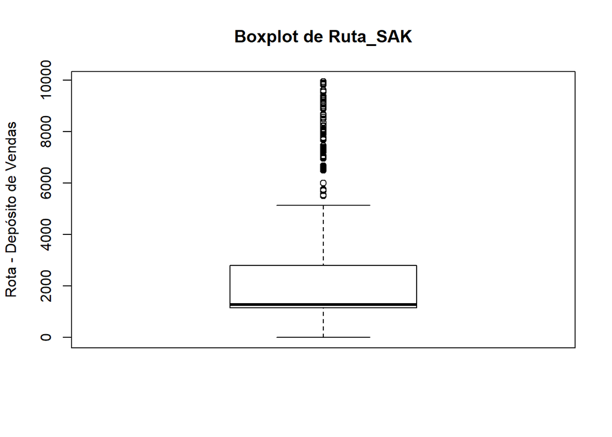

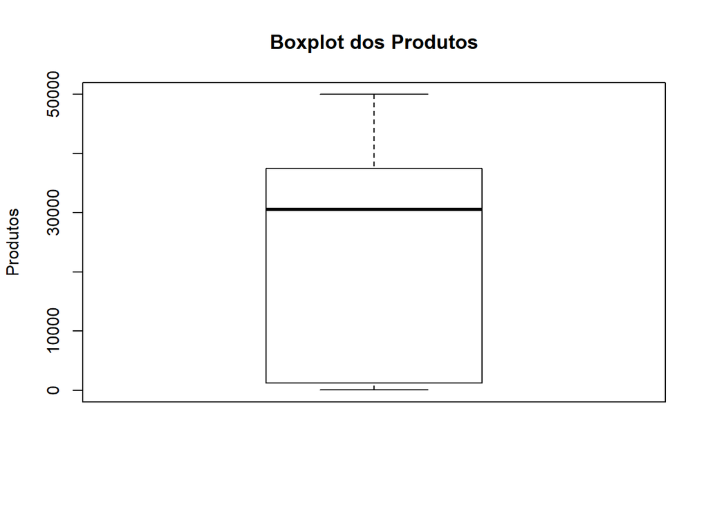

Verifica-se no gráfico de barras da variável target, abaixo, que embora a demanda concentra-se em até 30 unidades existem valores extremos da quantidade de demanda

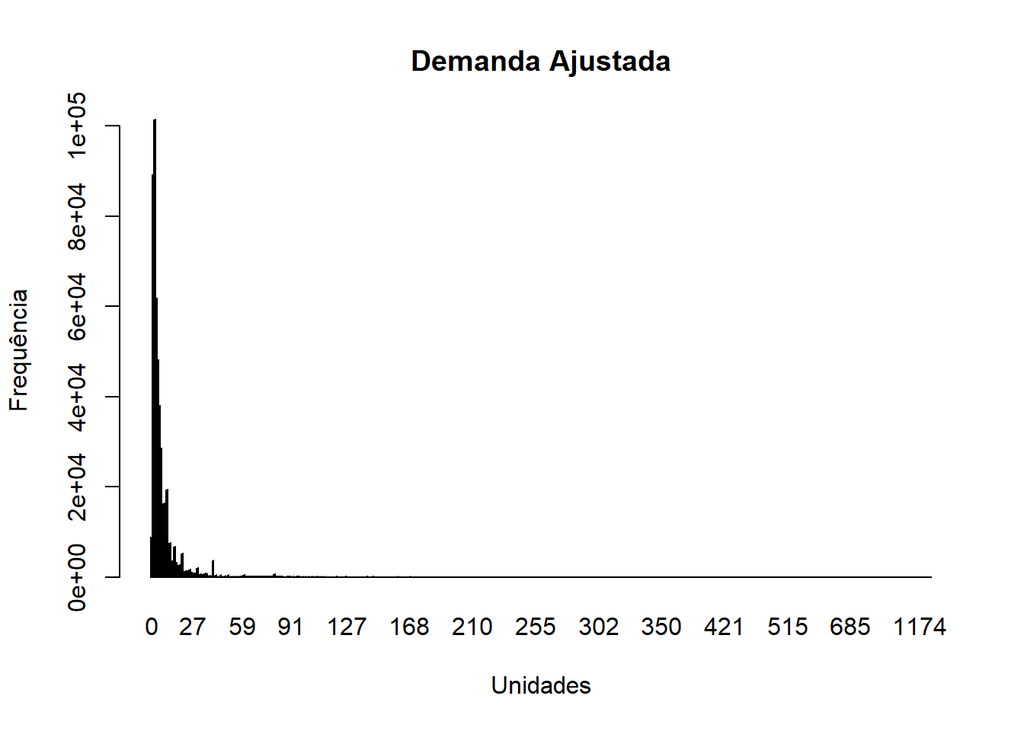

Observa-se nos gráficos a seguir que:

1. Na 3ª semana houve uma quantidade atípica vendida (mais de 4000 unidades).
2. As devoluções ultrapassaram 300 unidades na 3ª, 7ª e 9ª semana, sendo que só na terceira semana houve mais de 900 unidades devolvidas.
3. Verifica-se no scatter plot que existem picos de demanda em algumas rotas de depósito.

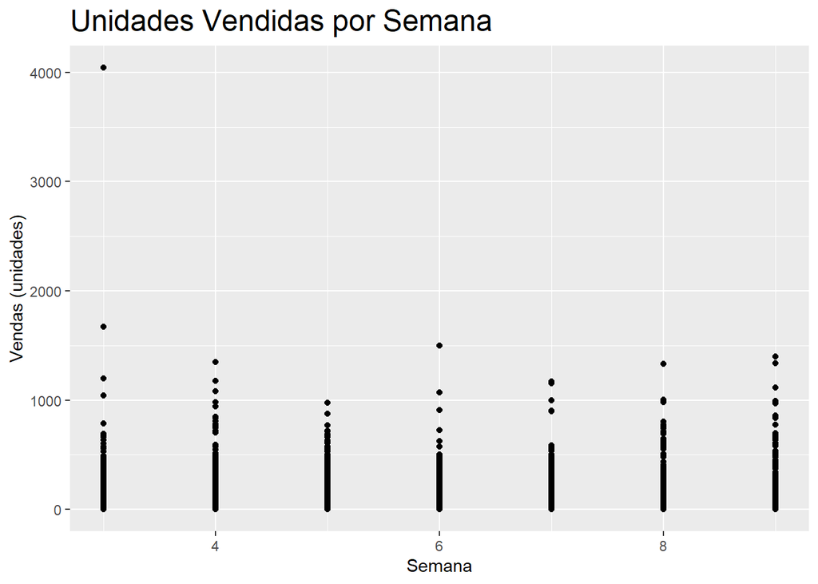

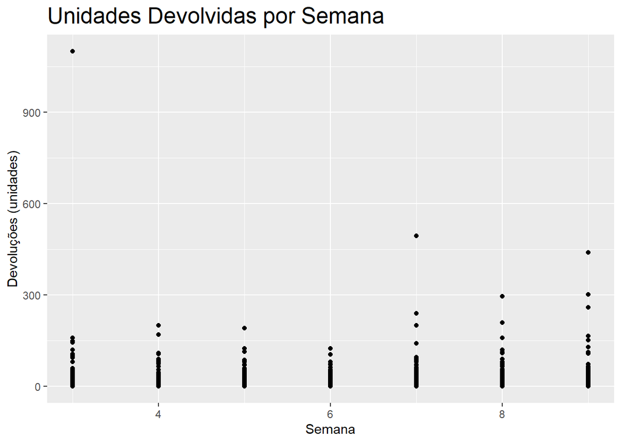

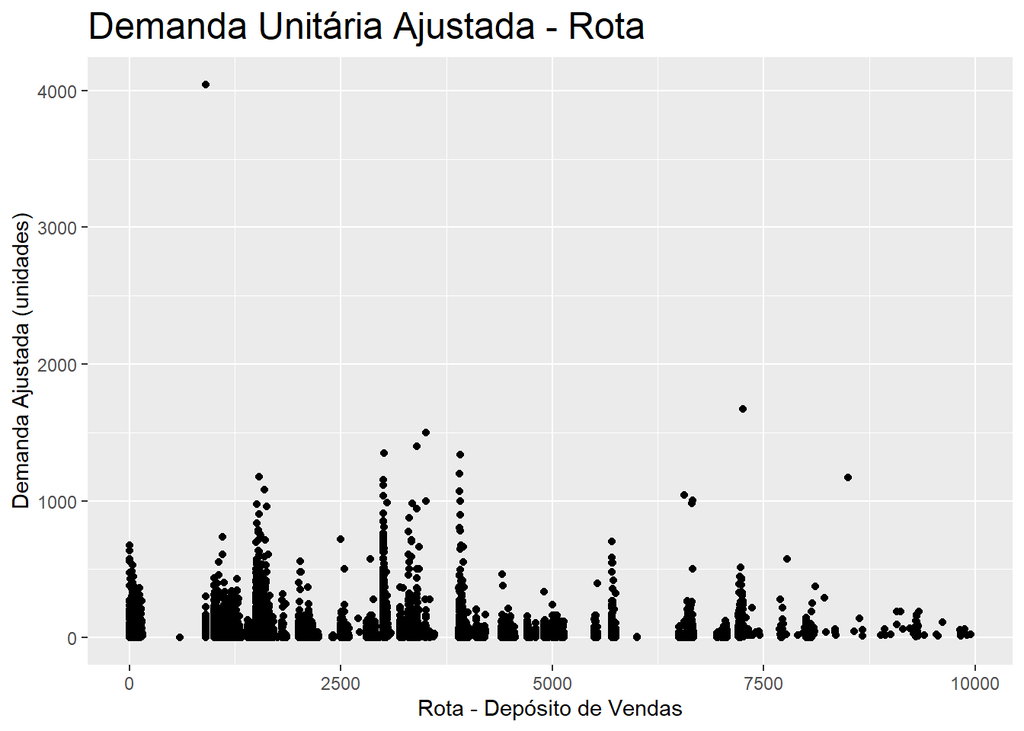

Verifica-se, a seguir, na matriz de correlação e também no corrplot que:

1. As variáveis ‘Venta_uni_hoy’ e ‘Venta_hoy’ possuem uma forte correlação positiva com a variável target ‘Demanda_uni_equil’, contudo estas variáveis não existem no arquivo de teste.
2. Dentre as demais variáveis, verifica-se que a variável ‘Canal_ID’ apresentou uma correlação (positiva) com a variável target um pouco maior do que as outras.

```
##                          Semana    Agencia_ID    Canal_ID     Ruta_SAK
## Semana             1.0000000000  0.0012136090  0.00907378 -0.001914630
## Agencia_ID         0.0012136090  1.0000000000 -0.04004501 -0.008296264
## Canal_ID           0.0090737804 -0.0400450065  1.00000000  0.473641320
## Ruta_SAK          -0.0019146298 -0.0082962637  0.47364132  1.000000000
## Cliente_ID         0.0060034287  0.0186967845  0.07588688  0.081985492
## Producto_ID        0.0130240356  0.0093227392  0.02940785  0.284080475
## Venta_uni_hoy      0.0032025331 -0.0066875093  0.13559840  0.054688752
## Venta_hoy         -0.0008942302 -0.0083695464  0.12791918  0.028907794
## Dev_uni_proxima    0.0032349732 -0.0004281906  0.02484947  0.002941676
## Dev_proxima        0.0006122959 -0.0005704430  0.02657910 -0.004135948
## Demanda_uni_equil  0.0028751754 -0.0066821782  0.13532379  0.055418642
##                     Cliente_ID Producto_ID Venta_uni_hoy     Venta_hoy
## Semana             0.006003429 0.013024036   0.003202533 -0.0008942302
## Agencia_ID         0.018696784 0.009322739  -0.006687509 -0.0083695464
## Canal_ID           0.075886883 0.029407855   0.135598397  0.1279191764
## Ruta_SAK           0.081985492 0.284080475   0.054688752  0.0289077941
## Cliente_ID         1.000000000 0.001053131  -0.013512335 -0.0156005680
## Producto_ID        0.001053131 1.000000000   0.048403304  0.0172228165
## Venta_uni_hoy     -0.013512335 0.048403304   1.000000000  0.8050793413
## Venta_hoy         -0.015600568 0.017222816   0.805079341  1.0000000000
## Dev_uni_proxima   -0.004288910 0.012549684   0.093090771  0.0766648288
## Dev_proxima       -0.005465164 0.008057423   0.113246756  0.1257325706
## Demanda_uni_equil -0.013079275 0.048005369   0.998097960  0.8031009713
##                   Dev_uni_proxima   Dev_proxima Demanda_uni_equil
## Semana               0.0032349732  0.0006122959       0.002875175
## Agencia_ID          -0.0004281906 -0.0005704430      -0.006682178
## Canal_ID             0.0248494709  0.0265790997       0.135323794
## Ruta_SAK             0.0029416765 -0.0041359480       0.055418642
## Cliente_ID          -0.0042889100 -0.0054651645      -0.013079275
## Producto_ID          0.0125496836  0.0080574233       0.048005369
## Venta_uni_hoy        0.0930907706  0.1132467558       0.998097960
## Venta_hoy            0.0766648288  0.1257325706       0.803100971
## Dev_uni_proxima      1.0000000000  0.8334640336       0.055485709
## Dev_proxima          0.8334640336  1.0000000000       0.073804878
## Demanda_uni_equil    0.0554857087  0.0738048783       1.000000000
```

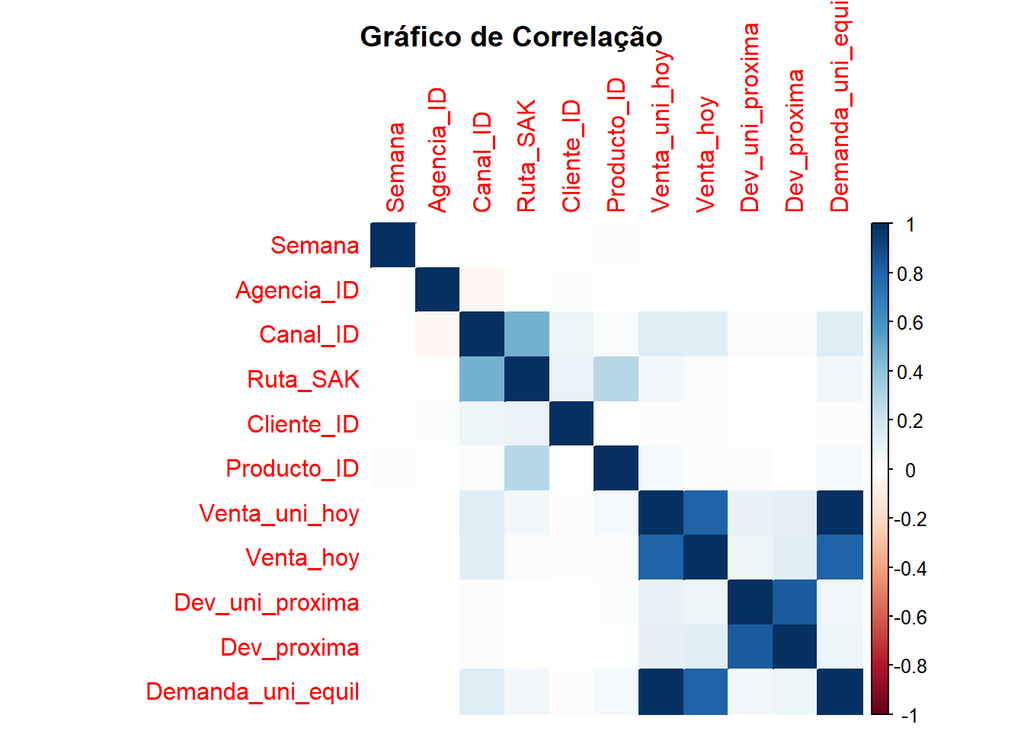

## Pré-processamento dos Dados

Carregando as tabelas de produtos, local/estado e clientes

```
## [1] 2592    2
```

```
## [1] 790   3
```

```
## [1] 935362      2
```

Eliminando as duplicidades da variável Cliente_ID e mantendo apenas o primeiro registro.

Merge das tabelas de produtos, local e clientes com os dados

```
## [1] 500000     15
```

### Features Engineering

Criando novas variáveis

Sumarizando os dados das semanas de 3 a 9 e agrupando por produto e local para calcular o valor médio das unidades vendidas e das devolvidas e adicioná-las aos dados:

Sumarizando os dados das semanas de 3 a 9 e agrupando por Agencia_ID e Ruta_SAK para calcular o valor médio das unidades vendidas e das devolvidas e adicioná-las aos dados:

Sumarizando os dados das semanas de 3 a 9 e agrupando por Ruta_SAK e Producto_ID para calcular o valor médio das unidades vendidas e das devolvidas e adicioná-las aos dados:

Sumarizando os dados das semanas de 3 a 9 e agrupando por cliente e canal para calcular o valor médio das unidades vendidas e das devolvidas e adicioná-las aos dados:

### Feature Selection

Verificando a correlação com a inclusão das novas variáveis para a seleção das variáveis mais relevantes para o modelo.

Definindo as colunas para verificar a correlação.

Observa-se na matriz de correlação que:

1. As variáveis adicionadas aos dados ‘Venta_uni_media’ das combinações (Rota-Produto, Produto-Agência, Agência-Rota e Cliente-Canal apresentaram uma correlação mais forte com a variável target Demanda_uni_equil.
2. As combinações da variável adicionada “Dev_uni” (unidades devolvidas) não apresentaram uma correlação significativa com a variável target “Demanda_uni_equil”.

```
##                                 Semana    Agencia_ID    Canal_ID     Ruta_SAK
## Semana                    1.0000000000  0.0012136090  0.00907378 -0.001914630
## Agencia_ID                0.0012136090  1.0000000000 -0.04004501 -0.008296264
## Canal_ID                  0.0090737804 -0.0400450065  1.00000000  0.473641320
## Ruta_SAK                 -0.0019146298 -0.0082962637  0.47364132  1.000000000
## Cliente_ID                0.0060034287  0.0186967845  0.07588688  0.081985492
## Producto_ID               0.0130240356  0.0093227392  0.02940785  0.284080475
## Venta_uni_hoy             0.0032025331 -0.0066875093  0.13559840  0.054688752
## Venta_hoy                -0.0008942302 -0.0083695464  0.12791918  0.028907794
## Dev_uni_proxima           0.0032349732 -0.0004281906  0.02484947  0.002941676
## Dev_proxima               0.0006122959 -0.0005704430  0.02657910 -0.004135948
## custo_unidade                       NA            NA          NA           NA
## Venta_uni_media           0.0066456081 -0.0087386474  0.13315402  0.049976739
## Dev_uni_media            -0.0008541782 -0.0009730355  0.03539564  0.014383108
## Venta_uni_AgRota_media    0.0014176889 -0.0096594593  0.19619389  0.079047052
## Dev_uni_AgRota_media      0.0015815575 -0.0019042421  0.06728670  0.015347350
## Venta_uni_RotaProd_media  0.0055959086 -0.0090683802  0.15755792  0.063345500
## Dev_uni_RotaProd_media    0.0017001491 -0.0013469368  0.04501576  0.011525456
## Venta_uni_CliCa_media     0.0023814275 -0.0099527781  0.20017259  0.083082110
## Dev_uni_CliCa_media      -0.0009762384 -0.0012899305  0.03218058  0.004189308
## Demanda_uni_equil         0.0028751754 -0.0066821782  0.13532379  0.055418642
##                            Cliente_ID Producto_ID Venta_uni_hoy     Venta_hoy
## Semana                    0.006003429 0.013024036   0.003202533 -0.0008942302
## Agencia_ID                0.018696784 0.009322739  -0.006687509 -0.0083695464
## Canal_ID                  0.075886883 0.029407855   0.135598397  0.1279191764
## Ruta_SAK                  0.081985492 0.284080475   0.054688752  0.0289077941
## Cliente_ID                1.000000000 0.001053131  -0.013512335 -0.0156005680
## Producto_ID               0.001053131 1.000000000   0.048403304  0.0172228165
## Venta_uni_hoy            -0.013512335 0.048403304   1.000000000  0.8050793413
## Venta_hoy                -0.015600568 0.017222816   0.805079341  1.0000000000
## Dev_uni_proxima          -0.004288910 0.012549684   0.093090771  0.0766648288
## Dev_proxima              -0.005465164 0.008057423   0.113246756  0.1257325706
## custo_unidade                      NA          NA            NA            NA
## Venta_uni_media           0.004923964 0.064301071   0.751845691  0.6537344429
## Dev_uni_media            -0.003601126 0.028587256   0.133660257  0.1114947272
## Venta_uni_AgRota_media   -0.018459231 0.052670513   0.690568541  0.6341336062
## Dev_uni_AgRota_media     -0.008411888 0.025123186   0.159590457  0.1361446531
## Venta_uni_RotaProd_media -0.008719962 0.056010157   0.860500848  0.7237963685
## Dev_uni_RotaProd_media   -0.004758840 0.025012942   0.146166161  0.1207760357
## Venta_uni_CliCa_media    -0.024125432 0.057391137   0.678839026  0.6285428732
```

[output cut: 92 more lines]

```
## Producto_ID                     0.0134323274       0.048005369
## Venta_uni_hoy                   0.0756884090       0.998097960
## Venta_hoy                       0.0651877847       0.803100971
## Dev_uni_proxima                 0.7658777231       0.055485709
## Dev_proxima                     0.6568397321       0.073804878
## custo_unidade                             NA                NA
## Venta_uni_media                 0.0747686477       0.748028091
## Dev_uni_media                   0.3127642858       0.103588917
## Venta_uni_AgRota_media          0.1036508329       0.686647238
## Dev_uni_AgRota_media            0.3022559868       0.132249274
## Venta_uni_RotaProd_media        0.0833169464       0.856203387
## Dev_uni_RotaProd_media          0.3903566794       0.109182667
## Venta_uni_CliCa_media           0.1115826042       0.675592519
## Dev_uni_CliCa_media             1.0000000000       0.061323943
## Demanda_uni_equil               0.0613239426       1.000000000
```

### Divisão em Dados de Treino e de Validação

Treinaremos o modelo com os dados das semanas de 3 a 7 e os dados das semanas 8 e 9 serão utilizados para a validação do modelo.

Verificando a proporção obtida para os dados de treino e de validação.

```
## [1] 72
```

```
## [1] 28
```

## Construção dos Modelos Preditivos

### Primeiro Modelo: Regressão Linear sem Seleção de Variáveis (dados originais)

Avaliando a performance do modelo

```
##
## Call:
## lm(formula = Demanda_uni_equil ~ Semana + Agencia_ID + Canal_ID +
##     Ruta_SAK + Cliente_ID + Producto_ID, data = dados_treino)
##
## Residuals:
##    Min     1Q Median     3Q    Max
##  -28.4   -4.9   -3.2   -0.1 4037.3
##
## Coefficients:
##               Estimate Std. Error t value Pr(>|t|)
## (Intercept)  4.238e+00  1.402e-01  30.229   <2e-16 ***
## Semana       3.189e-02  2.397e-02   1.330    0.183
## Agencia_ID  -4.342e-06  8.330e-06  -0.521    0.602
## Canal_ID     2.064e+00  2.670e-02  77.310   <2e-16 ***
## Ruta_SAK    -3.677e-04  2.721e-05 -13.516   <2e-16 ***
## Cliente_ID  -2.356e-07  1.849e-08 -12.738   <2e-16 ***
## Producto_ID  5.608e-05  1.915e-06  29.289   <2e-16 ***
## ---
## Signif. codes:  0 '***' 0.001 '**' 0.01 '*' 0.05 '.' 0.1 ' ' 1
##
## Residual standard error: 20.37 on 359380 degrees of freedom
## Multiple R-squared:  0.02071,    Adjusted R-squared:  0.02069
## F-statistic:  1267 on 6 and 359380 DF,  p-value: < 2.2e-16
```

Testando o modelo nos dados de validação

Calculando as métricas RMSE (root mean squared error) e RMSLE (root mean squared logarithmic error)

```
## [1] 20.30667
```

```
## [1] 0.9566147
```

### Segundo Modelo: Regressão Linear com Seleção das Variáveis Criadas (Novas)

Avaliando a performance do modelo

```
##
## Call:
## lm(formula = Demanda_uni_equil ~ Venta_uni_RotaProd_media + Venta_uni_media +
##     Venta_uni_AgRota_media + Venta_uni_CliCa_media, data = dados_treino)
##
## Residuals:
##     Min      1Q  Median      3Q     Max
## -885.45   -2.08   -0.59    0.98 1996.09
##
## Coefficients:
##                           Estimate Std. Error t value Pr(>|t|)
## (Intercept)              -1.764078   0.018866  -93.50   <2e-16 ***
## Venta_uni_RotaProd_media  0.650505   0.001773  366.85   <2e-16 ***
## Venta_uni_media           0.137061   0.001823   75.18   <2e-16 ***
## Venta_uni_AgRota_media    0.284605   0.001587  179.32   <2e-16 ***
## Venta_uni_CliCa_media     0.162640   0.001664   97.77   <2e-16 ***
## ---
## Signif. codes:  0 '***' 0.001 '**' 0.01 '*' 0.05 '.' 0.1 ' ' 1
##
## Residual standard error: 9.754 on 359382 degrees of freedom
## Multiple R-squared:  0.7754, Adjusted R-squared:  0.7754
## F-statistic: 3.103e+05 on 4 and 359382 DF,  p-value: < 2.2e-16
```

Testando o modelo nos dados de validação

Calculando a métrica RMSE (root mean squared error)

```
## [1] 10.05793
```

Substituindo por zero os (7) valores previstos negativos para a variável target (Demanda_uni_equil) para calcular o RMSLE (root mean squared logarithmic error).

```
## [1] 0.5868569
```

### Terceiro Modelo: XGBOOST (eXtreme Gradient Boosting)

Suprimindo warninngs

Vetor com as variáveis novas selecionadas (maior correlação com a variável target)

Transformando os datasets em matriz densa.

Watchlist com os datasets para a avaliação do RMSE em cada iteração.

Treinando o modelo

[output not shown]

Print do modelo treinado

```
## ##### xgb.Booster
## raw: 346.1 Kb
## call:
##   xgb.train(data = dtreino, nrounds = 1000, watchlist = watchlist,
##     print_every_n = 100, early_stopping_rounds = 10, max.depth = 5,
##     eta = 0.1, nthread = 2, objective = "reg:squarederror")
## params (as set within xgb.train):
##   max_depth = "5", eta = "0.1", nthread = "2", objective = "reg:squarederror", validate_parameters = "TRUE"
## xgb.attributes:
##   best_iteration, best_msg, best_ntreelimit, best_score, niter
## callbacks:
##   cb.print.evaluation(period = print_every_n)
##   cb.evaluation.log()
##   cb.early.stop(stopping_rounds = early_stopping_rounds, maximize = maximize,
##     verbose = verbose)
## # of features: 4
## niter: 129
## best_iteration : 119
## best_ntreelimit : 119
## best_score : 8.485119
## best_msg : [119] train-rmse:6.929246 valid-rmse:8.485119
## nfeatures : 4
## evaluation_log:
##     iter train_rmse valid_rmse
##        1  19.970451  19.910011
##        2  18.509552  18.483404
## ---
##      128   6.895222   8.490869
##      129   6.891915   8.490106
```

Previsões com os dados de validação

Substituindo por zero os valores previstos negativos para a variável target(Demanda_uni_equil) e calculando o RMSLE.

```
## [1] 0.5255711
```

Calculando os resíduos

Plot dos resíduos

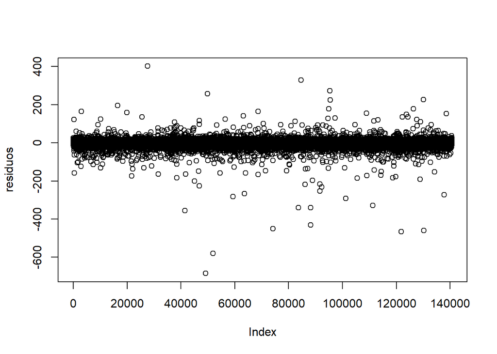

Calculando o coeficiente de determinação (R2)

Imprimindo o coeficiente de determinação (R2) calculado.

```
## [1] "Coeficiente de determinação do modelo XGBoost: 0.829207005106691"
```

## Avaliação dos Modelos Preditivos

1. O coeficiente de determinação (R2) do modelo de regressão linear somente com as variáveis originais foi muito baixo (0.02), indicando que o modelo não se ajusta aos dados. As métricas RMSE e RMSLE comprovam o baixo desempenho deste modelo: RMSE = 20.307 e RMSLE = 0.96
2. O modelo de regressão linear com seleção de novas variáveis melhorou o coeficiente de determinação (R2 de 0.7754). O RMSE do modelo com a seleção de novas variáveis foi menor (RMSE de 10.058). O RMSLE do modelo com a seleção de novas variáveis de 0.587 indica que o desempenho deste modelo foi mais razoável comparado ao modelo anterior.
3. O modelo XGBoost apresentou uma melhor performance do que o modelo de regressão linear com seleção de novas variáveis. R2 do XGBoost = 0.829 (maior do que o R2 do modelo de regressão linear). As métricas RMSE e RMSLE obtidas com o XGBoost de 8.485 e 0.526, respectivamente, foram menores do que as do modelo de regressão linear.

*** Conclusão: Melhor Modelo -> XGBoost ***